# Survey Results Task 3.3 731951

Anja Rainer

25 Oktober, 2021

```r
# number of cases:
nrow(df)
```

```
## [1] 167
```

Our sample is based on 167 cases.

# Missing data

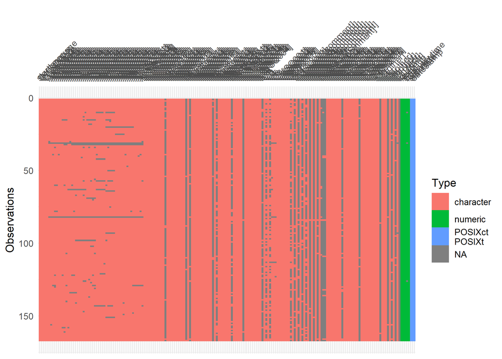

```r
library(visdat)
vis_dat(df)
```

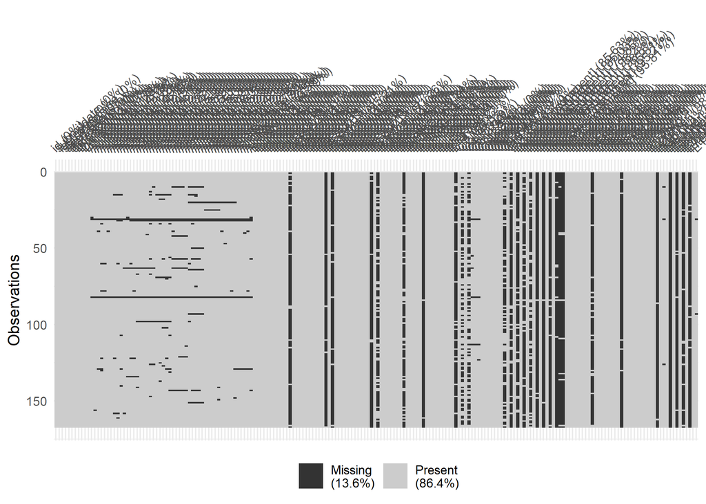

```r
visdat::vis_miss(df)
```

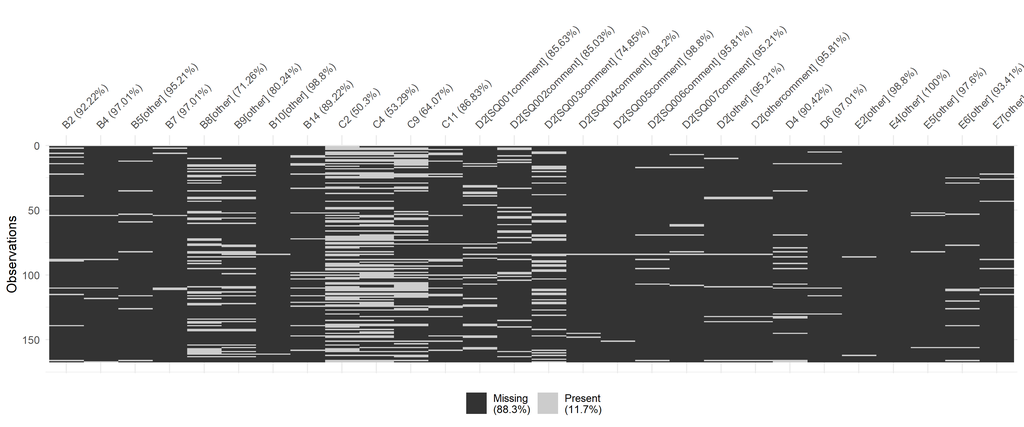

```r
df %>%
  select_if(function(x) (sum(is.na(x)))/length(x) > .1) %>%
  vis_miss()
```

# Countries

In which country do you work? [drop-down/ open text]

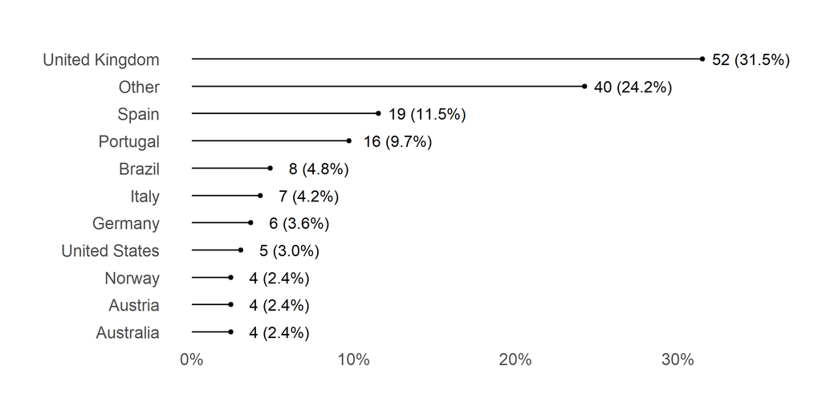

```r
e1_rec_df <- df %>%
  select("E1_rec")

e1_rec_df %>%
  mutate(E1_rec = forcats::fct_lump_min(E1_rec, min = 4, other_level = "Other")) %>%
  plot_bar(E1_rec, title = "Countries", reorder = TRUE, nudge_y = .03)
```

# Gender

Please select the gender category that best describes you

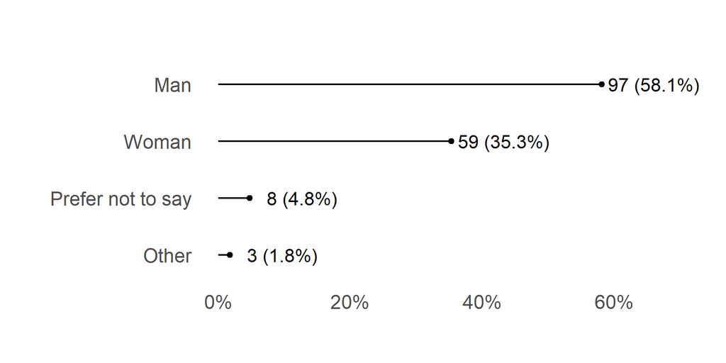

```r
answer_levels_e2 <- c("Man", "Woman", "Prefer not to say", "Other")

e2_df <- df %>%
  select("E2")

e2_df_rec <- e2_df %>%
  mutate(across(.fns = factor, levels = answer_levels_e2))


e2_df_rec %>%
  plot_bar(E2, title = "Gender", reorder = TRUE, nudge_y = .079)
```

# Age cohorts

What is your age?

```r
answer_levels_e3 <- c("<20", "20-29", "30-39", "40-49", "50-59", "60-69", "70+")

e3_df <- df %>%
  select("E3")

e3_df_rec <- e3_df %>%
  mutate(across(.fns = factor, levels = answer_levels_e3))


e3_df_rec %>%
  mutate(across(.fns = as.numeric)) %>%
  summarise(across(everything(), ~mean(.x, na.rm = TRUE)))
```

```
## # A tibble: 1 x 1
##      E3
##   <dbl>
## 1  4.49
```

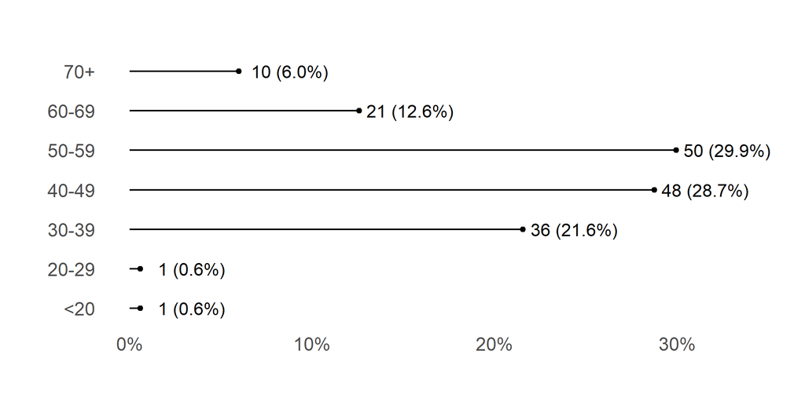

```r
e3_df_rec %>%
  plot_bar(E3, title = "Age cohorts", reorder = FALSE, nudge_y = .028)
```

# Publish first academic publication

When did you publish your first academic publication (journal article, book, chapter, conference proceeding, or similar)? Please tell us the year.

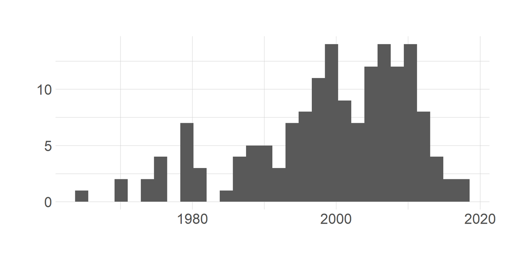

```r
e3b_df <- df %>%
  select("E3b") %>%
  filter(E3b > 1960)

e3b_df %>%
  ggplot(aes(E3b)) +
  geom_histogram() +
  labs(x = NULL, y = NULL, title = NULL) +
  hrbrthemes::theme_ipsum(base_family = "Hind")
```

# Highest education

What is the highest education level you completed? [drop down]

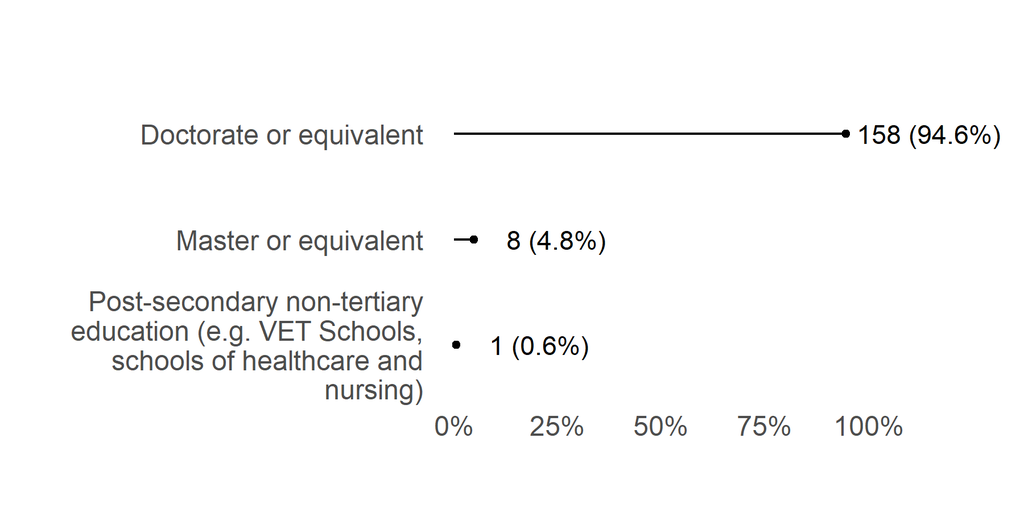

```r
answer_levels_e4 <- c("Post-secondary non-tertiary education (e.g. VET Schools, schools of healthcare and nursing)", "Short-cycle tertiary education (e.g. master schools, colleges, vocational training schools)", "Bachelor or equivalent", "Master or equivalent", "Doctorate or equivalent", "Other")

answer_labels_e4 <- str_wrap(answer_levels_e4, 30)

e4_df <- df %>%
  select("E4")

e4_df_rec <- e4_df %>%
  mutate(across(.fns = factor, levels = answer_levels_e4,
                labels = answer_labels_e4))

e4_df_rec %>%
  plot_bar(E4, title = "Highest education", reorder = FALSE, nudge_y = .2) +
  scale_y_continuous(breaks = c(0, .25, .5, .75, 1),
                     labels = function(x) scales::percent(x, accuracy = 1))
```

# Types of institution

In what type of institution do you work? [drop down]

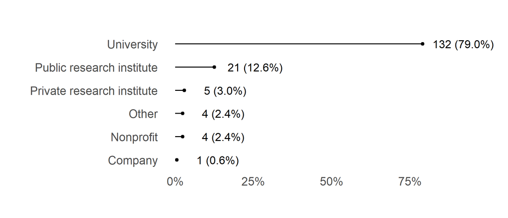

```r
answer_levels_e5 <- c("University", "Public research institute", "Private research institute", "Company", "Nonprofit", "Other")

e5_df <- df %>%
  select("E5")

e5_df_rec <- e5_df %>%
  mutate(across(.fns = factor, levels = answer_levels_e5))

e5_df_rec %>%
  plot_bar(E5, title = "Types of institution", reorder = TRUE, nudge_y = .13)
```

# Position

What is your position? Choose all that apply

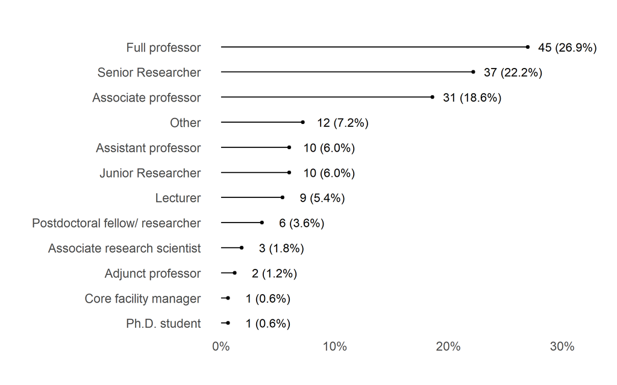

```r
answer_levels_e6 <- c("Junior Researcher", "Senior Researcher", "Ph.D. student", "Postdoctoral fellow/ researcher", "Assistant professor",
                      "Associate professor", "Full professor", "Associate research scientist", "Instructor", "Lecturer", "Adjunct professor",
                      "Technician or lab manager", "Core facility manager", "Other")

e6_df <- df %>%
  select("E6")

e6_df_rec <- e6_df %>%
  mutate(across(.fns = factor, levels = answer_levels_e6))

e6_df_rec %>%
  plot_bar(E6, title = "Position", reorder = TRUE, nudge_y = .035)
```

# Respondents by disciplines

In which general area of knowledge do you work?

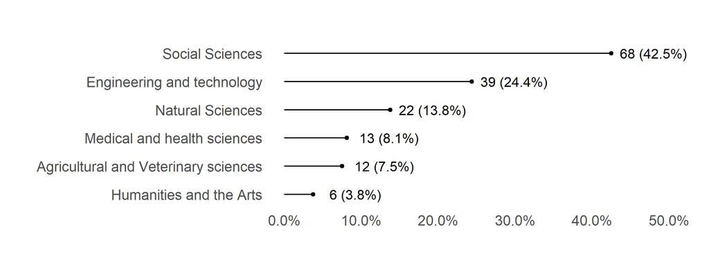

```r
answer_levels_e7 <- c("Natural Sciences", "Engineering and technology", "Medical and health sciences", "Agricultural and Veterinary sciences",
                      "Social Sciences", "Humanities and the Arts")

e7_df <- df %>%
  select("E7")

e7_df_rec <- e7_df %>%
  mutate(across(.fns = factor, levels = answer_levels_e7))

e7_df_rec %>%
  plot_bar(E7, title = "Respondents by disciplines", reorder = TRUE, nudge_y = .055)
```

# A1 Practices in OS

Please rate the following statements according to your practices regarding Open Science

```r
answer_levels <- c("Strongly disagree", "Disagree", "Neither agree nor disagree",
                   "Agree", "Strongly agree",
                   "This topic is not relevant to my research",
                   "Don’t know/ Don’t have enough information")


a1_df <- df %>%
  select(starts_with("A1["))

a1_df_rec <- a1_df %>%
  mutate(across(.fns = factor, levels = answer_levels))


recode_successful(a1_df, a1_df_rec)
```

[1] TRUE

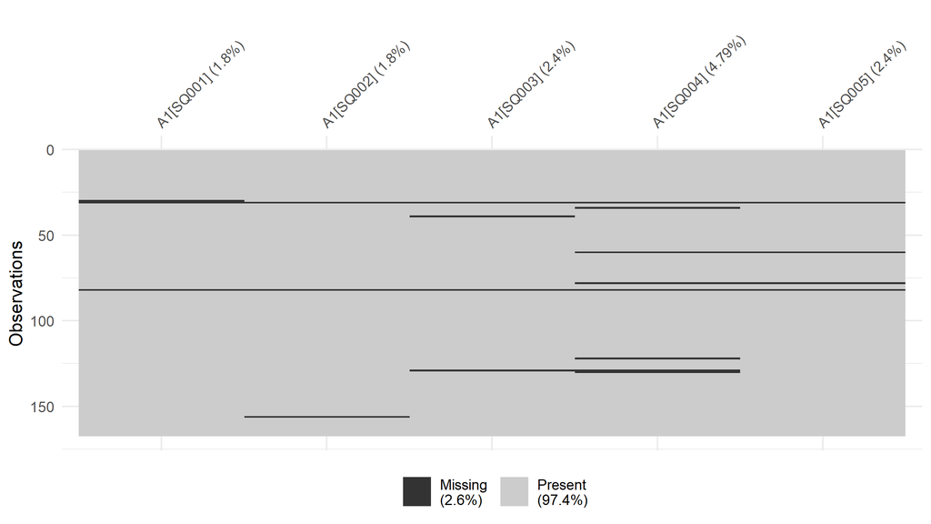

```r
visdat::vis_miss(a1_df_rec)
```

| Variable | Strongly disagree | Disagree | Neither agree nor disagree | Agree | Strongly agree |
| --- | --- | --- | --- | --- | --- |
| I make an effort to make my research collaborative | 4 (2.5%) | 2 (1.2%) | 14 (8.6%) | 62 (38.0%) | 81 (49.7%) |
| I make an effort to make my research open | 3 (1.9%) | 3 (1.9%) | 14 (8.6%) | 69 (42.6%) | 73 (45.1%) |
| Open science consists of different dimensions (e.g. publications, data, code, methods) | 4 (2.7%) | 8 (5.4%) | 12 (8.1%) | 74 (50.0%) | 50 (33.8%) |
| Open science is different from traditional research approaches | 5 (3.3%) | 31 (20.4%) | 38 (25.0%) | 52 (34.2%) | 26 (17.1%) |
| Open science values transparency in research | 5 (3.2%) | 2 (1.3%) | 12 (7.6%) | 46 (29.3%) | 92 (58.6%) |

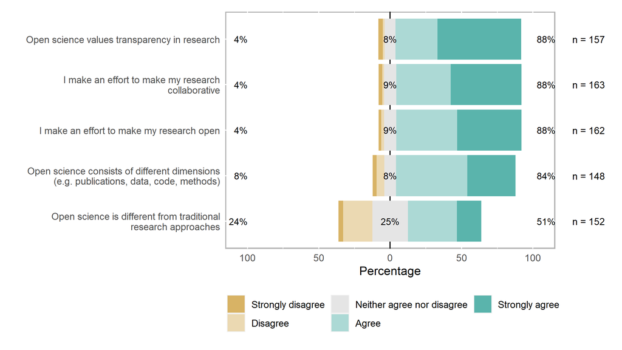

```r
a1_df_rec %>%
  plot_likert()
```

# A2 Own practices regarding Open Access publishing

Please rate the following statements according to your own practices regarding Open Access publishing.

| Variable | Never | Rarely | Sometimes | Often | Always |
| --- | --- | --- | --- | --- | --- |
| I deposit my preprints in a disciplinary preprint repository | 30 (20.1%) | 30 (20.1%) | 32 (21.5%) | 22 (14.8%) | 35 (23.5%) |
| I deposit my publications in a repository | 2 (1.2%) | 10 (6.2%) | 20 (12.3%) | 43 (26.5%) | 87 (53.7%) |
| I know how to get funding for open access publication fees | 21 (14.5%) | 29 (20.0%) | 38 (26.2%) | 36 (24.8%) | 21 (14.5%) |
| I publish in open-access journals | 8 (4.9%) | 22 (13.5%) | 60 (36.8%) | 64 (39.3%) | 9 (5.5%) |
| I publish my publications under an open license | 7 (4.7%) | 21 (14.1%) | 47 (31.5%) | 54 (36.2%) | 20 (13.4%) |

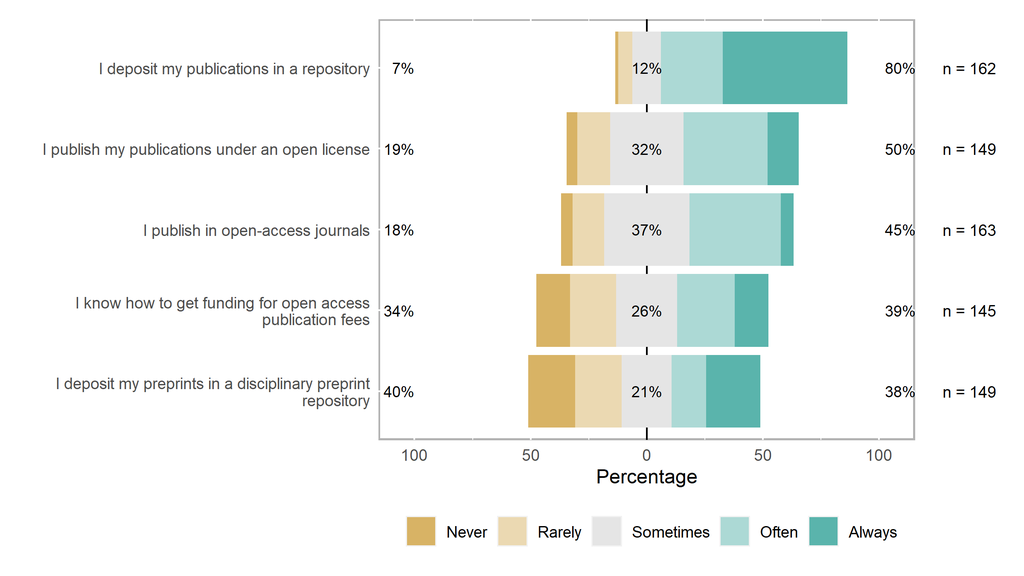

```r
answer_levels_2 <- c("Never", "Rarely", "Sometimes",
                   "Often", "Always", "This topic is not relevant to my research",
                   "Don’t know/ Don’t have enough information")


a2_df <- df %>%
  select(starts_with("A2["))

a2_df_rec <- a2_df %>%
  mutate(across(.fns = factor, levels = answer_levels_2))

a2_df_rec %>%
  plot_likert(legend_rows = 1)
```

# A3 Own practices regarding Research Data Management

Please rate the following statements according to your own practices regarding Research Data Management.

| Variable | Never | Rarely | Sometimes | Often | Always |
| --- | --- | --- | --- | --- | --- |
| I develop a data management plan | 17 (11.9%) | 30 (21.0%) | 41 (28.7%) | 32 (22.4%) | 23 (16.1%) |
| I publish my data under a license | 58 (49.2%) | 23 (19.5%) | 16 (13.6%) | 14 (11.9%) | 7 (5.9%) |
| I publish my data’s description along with its identifier (DOI, handle ,…) | 33 (23.7%) | 21 (15.1%) | 22 (15.8%) | 38 (27.3%) | 25 (18.0%) |
| I share my data in a data repository | 35 (24.8%) | 31 (22.0%) | 28 (19.9%) | 28 (19.9%) | 19 (13.5%) |
| When submitting an article, I make sure my data can be accessed by the reviewers | 29 (20.6%) | 26 (18.4%) | 35 (24.8%) | 23 (16.3%) | 28 (19.9%) |

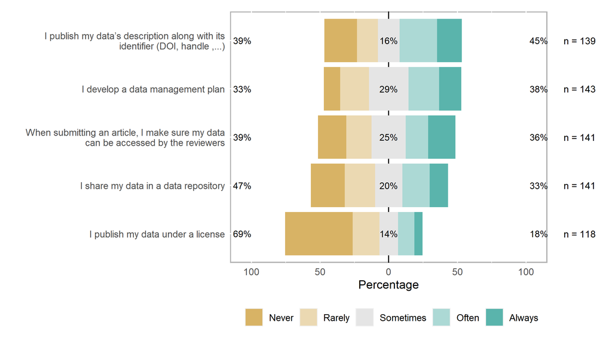

```r
a3_df <- df %>%
  select(starts_with("A3["))

a3_df_rec <- a3_df %>%
  mutate(across(.fns = factor, levels = answer_levels_2))

a3_df_rec %>%
  plot_likert(legend_rows = 1)
```

# A4 Practices regarding Reproducible Research

Please rate the following statements according to your practices regarding Reproducible Research

| Variable | Never | Rarely | Sometimes | Often | Always |
| --- | --- | --- | --- | --- | --- |
| I extensively document and give access to the methodology used for each finding | 5 (3.4%) | 8 (5.5%) | 25 (17.2%) | 49 (33.8%) | 58 (40.0%) |
| I foster results reproducibility | 6 (4.7%) | 4 (3.1%) | 23 (18.0%) | 44 (34.4%) | 51 (39.8%) |
| I pre-register my hypothesis | 67 (60.9%) | 20 (18.2%) | 14 (12.7%) | 5 (4.5%) | 4 (3.6%) |
| I share my electronic laboratory notebooks | 59 (68.6%) | 10 (11.6%) | 9 (10.5%) | 3 (3.5%) | 5 (5.8%) |
| I use platforms like open science framework or GitHub to share my research | 58 (43.9%) | 25 (18.9%) | 25 (18.9%) | 17 (12.9%) | 7 (5.3%) |

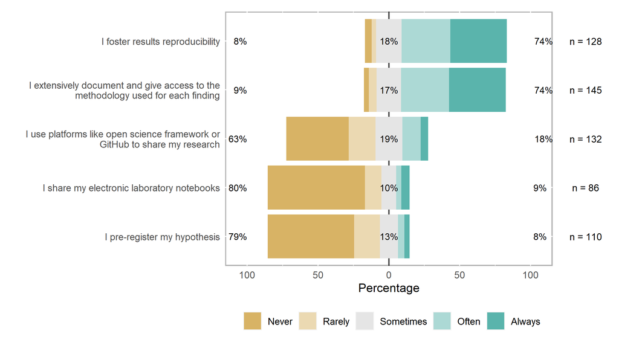

```r
a4_df <- df %>%
  select(starts_with("A4["))

a4_df_rec <- a4_df %>%
  mutate(across(.fns = factor, levels = answer_levels_2))

a4_df_rec %>%
  plot_likert(legend_rows = 1)
```

# A5 Practices regarding Open Peer Review

Please rate the following statements according to your practices regarding Open Peer Review.

| Variable | Strongly disagree | Disagree | Neither agree nor disagree | Agree | Strongly agree |
| --- | --- | --- | --- | --- | --- |
| I opt for journals that offer the open peer review option | 18 (14.0%) | 38 (29.5%) | 48 (37.2%) | 17 (13.2%) | 8 (6.2%) |
| I sign my reviews | 36 (26.5%) | 39 (28.7%) | 27 (19.9%) | 26 (19.1%) | 8 (5.9%) |
| Open peer review improves the transparency of the review process | 7 (4.9%) | 13 (9.2%) | 37 (26.1%) | 47 (33.1%) | 38 (26.8%) |
| Platforms that allow open peer review are easy to use | 2 (2.2%) | 8 (8.7%) | 42 (45.7%) | 28 (30.4%) | 12 (13.0%) |
| Reviewers’ comments are attentive in open peer-review | 6 (5.3%) | 4 (3.5%) | 55 (48.2%) | 32 (28.1%) | 17 (14.9%) |

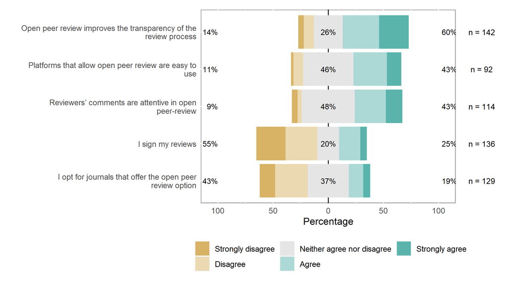

```r
answer_levels <- c("Strongly disagree", "Disagree", "Neither agree nor disagree",
                   "Agree", "Strongly agree",
                   "This topic is not relevant to my research",
                   "Don’t know/ Don’t have enough information")


a5_df <- df %>%
  select(starts_with("A5["))

a5_df_rec <- a5_df %>%
  mutate(across(.fns = factor, levels = answer_levels))

a5_df_rec %>%
  plot_likert()
```

# A6 Practices regarding Open Source Software

Please rate the following statements according to your practices regarding Open Source Software.

| Variable | Never | Rarely | Sometimes | Often | Always |
| --- | --- | --- | --- | --- | --- |
| I develop software collaboratively | 11 (15.7%) | 15 (21.4%) | 15 (21.4%) | 15 (21.4%) | 14 (20.0%) |
| I extensively document my software development methodology | 12 (16.0%) | 13 (17.3%) | 23 (30.7%) | 15 (20.0%) | 12 (16.0%) |
| I license my software to inform about the conditions under which it can be reused | 28 (38.4%) | 11 (15.1%) | 10 (13.7%) | 9 (12.3%) | 15 (20.5%) |
| I reuse and build upon open-source software | 14 (16.9%) | 12 (14.5%) | 23 (27.7%) | 23 (27.7%) | 11 (13.3%) |
| I share my software code (e.g. via GitHub, Figshare or Zenodo) | 21 (25.9%) | 14 (17.3%) | 13 (16.0%) | 21 (25.9%) | 12 (14.8%) |

[figure not shown]

```r
a6_df <- df %>%
  select(starts_with("A6["))

a6_df_rec <- a6_df %>%
  mutate(across(.fns = factor, levels = answer_levels_2))

a6_df_rec %>%
  plot_likert(legend_rows = 1)
```

# A7 Practices regarding Licensing

Please rate the following statements according to your practices regarding Licensing.

| Variable | Strongly disagree | Disagree | Neither agree nor disagree | Agree | Strongly agree |
| --- | --- | --- | --- | --- | --- |
| I feel confident that when some scientific output is licensed, people using it will respect the licensing terms | 5 (4.5%) | 12 (10.7%) | 32 (28.6%) | 43 (38.4%) | 20 (17.9%) |
| I license my publications | 16 (15.5%) | 11 (10.7%) | 26 (25.2%) | 36 (35.0%) | 14 (13.6%) |
| I tend to use licenses that enable some kind of reuse | 8 (7.5%) | 10 (9.4%) | 12 (11.3%) | 55 (51.9%) | 21 (19.8%) |
| I use Creative Commons licenses | 11 (9.8%) | 13 (11.6%) | 17 (15.2%) | 46 (41.1%) | 25 (22.3%) |
| Using a license will prevent unauthorised uses of my work | 6 (5.3%) | 30 (26.3%) | 31 (27.2%) | 32 (28.1%) | 15 (13.2%) |

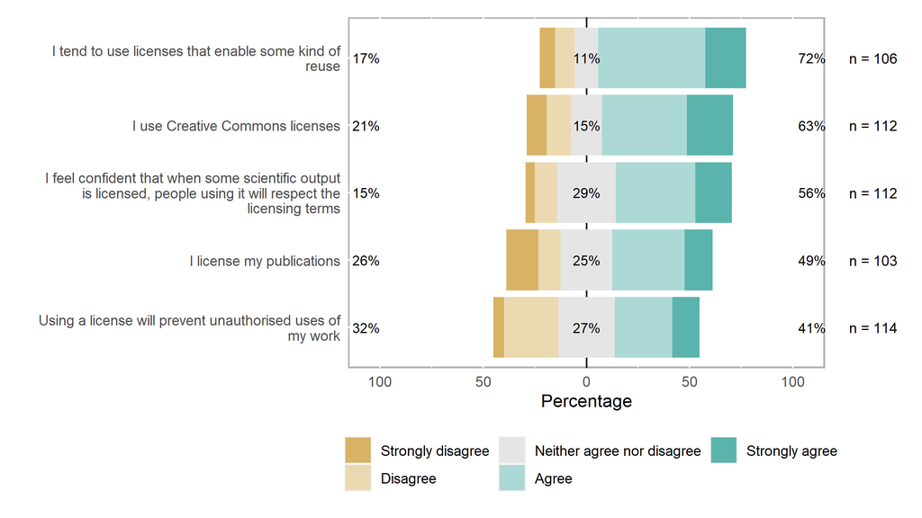

```r
a7_df <- df %>%
  select(starts_with("A7["))

a7_df_rec <- a7_df %>%
  mutate(across(.fns = factor, levels = answer_levels))

a7_df_rec %>%
  plot_likert()
```

# A8 Practices regarding Research Integrity

Please rate the following statements according to your practices regarding Research Integrity

| Variable | Sometimes | Often | Always | Never | Rarely |
| --- | --- | --- | --- | --- | --- |
| I acknowledge all intellectual contributions and cite related work correctly in my publications | 1 (0.6%) | 12 (7.5%) | 147 (91.9%) | NA | NA |
| I comply with codes and regulations relevant to my discipline | 3 (2.0%) | 13 (8.6%) | 133 (88.1%) | 1 (0.7%) | 1 (0.7%) |
| I inform subjects and ask for their consent prior to disseminating my research | 2 (1.9%) | 13 (12.6%) | 84 (81.6%) | 2 (1.9%) | 2 (1.9%) |
| I review publications without biases or influences | 4 (2.6%) | 22 (14.4%) | 123 (80.4%) | 4 (2.6%) | NA |
| I thoroughly inform my human subjects of all the details concerning their participation in my research | 2 (2.1%) | 11 (11.6%) | 81 (85.3%) | NA | 1 (1.1%) |

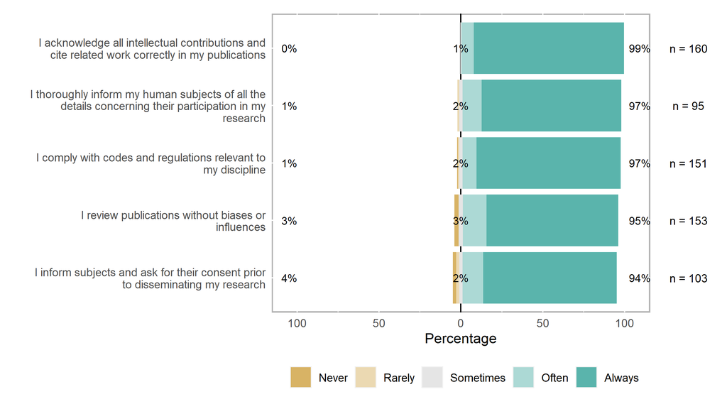

```r
a8_df <- df %>%
  select(starts_with("A8["))

a8_df_rec <- a8_df %>%
  mutate(across(.fns = factor, levels = answer_levels_2))

a8_df_rec %>%
  plot_likert(legend_rows = 1)
```

# A9 Practices regarding Citizen Science (information, consultation, public participation)

Please rate the following statements according to your practices regarding Citizen Science - consider all levels -information, consultation, public participation

| Variable | Strongly disagree | Disagree | Neither agree nor disagree | Agree | Strongly agree |
| --- | --- | --- | --- | --- | --- |
| I align my research with challenges relevant for society | 4 (2.6%) | 5 (3.2%) | 21 (13.6%) | 52 (33.8%) | 72 (46.8%) |
| I ask for the citizen scientist’s feedback during the research process | 22 (19.1%) | 20 (17.4%) | 24 (20.9%) | 31 (27.0%) | 18 (15.7%) |
| I involve citizens in data gathering for my research | 23 (20.2%) | 19 (16.7%) | 23 (20.2%) | 38 (33.3%) | 11 (9.6%) |
| I provide the public with the information they need to understand my research | 4 (2.6%) | 4 (2.6%) | 28 (17.9%) | 67 (42.9%) | 53 (34.0%) |
| I regularly publish news about my research | 12 (7.7%) | 29 (18.7%) | 41 (26.5%) | 47 (30.3%) | 26 (16.8%) |

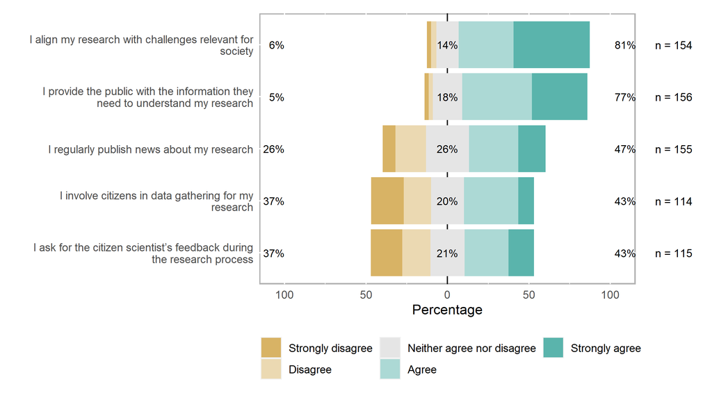

```r
a9_df <- df %>%
  select(starts_with("A9["))

a9_df_rec <- a9_df %>%
  mutate(across(.fns = factor, levels = answer_levels))

a9_df_rec %>%
  plot_likert()
```

# A10 Practices regarding Gender Issues

Please rate the following statements according to your practices regarding Gender issues

| Variable | Strongly disagree | Disagree | Neither agree nor disagree | Agree | Strongly agree |
| --- | --- | --- | --- | --- | --- |
| Gender equality is a concern in the constitution of my research team | 7 (5.1%) | 9 (6.5%) | 32 (23.2%) | 46 (33.3%) | 44 (31.9%) |
| I conduct a gender-blind research | 8 (7.8%) | 14 (13.6%) | 24 (23.3%) | 32 (31.1%) | 25 (24.3%) |
| I guarantee that the groups involved in the project (e.g. samples, testing groups) are gender-balanced | 8 (7.2%) | 13 (11.7%) | 34 (30.6%) | 34 (30.6%) | 22 (19.8%) |
| I look for gender equality when looking for project partners | 9 (6.3%) | 15 (10.5%) | 37 (25.9%) | 50 (35.0%) | 32 (22.4%) |
| I seek not to have imbalances in the decision-making process | 2 (1.4%) | 2 (1.4%) | 25 (17.0%) | 73 (49.7%) | 45 (30.6%) |

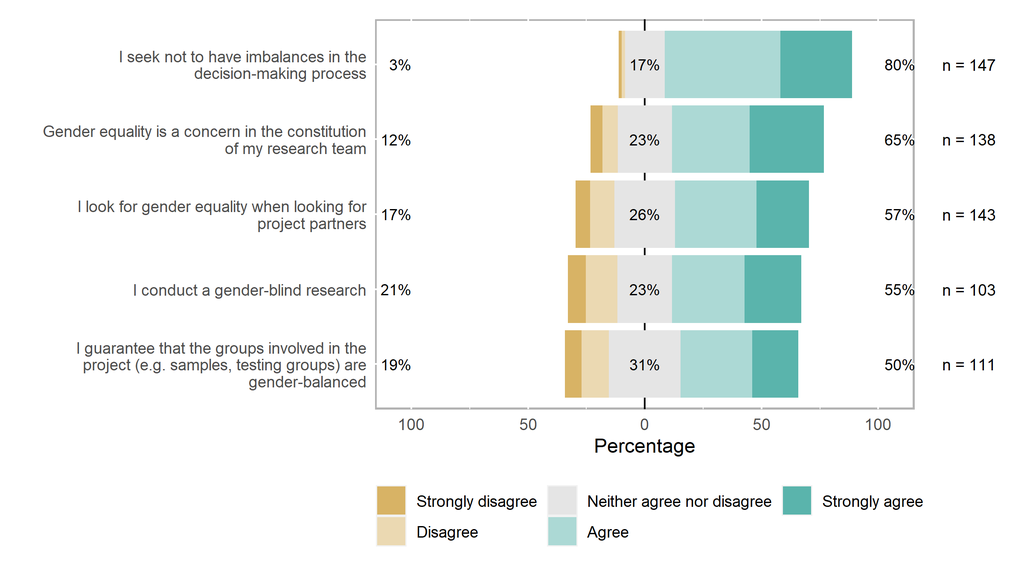

```r
a10_df <- df %>%
  select(starts_with("A10["))

a10_df_rec <- a10_df %>%
  mutate(across(.fns = factor, levels = answer_levels))

a10_df_rec %>%
  plot_likert()
```

# Part B Training on OS topics

# B1 Attended Training Events

How many training events have you attended in these topics?

| Variable | None | 1 | 2 | 3-5 |
| --- | --- | --- | --- | --- |
| Citizen science | 141 (86.0%) | 12 (7.3%) | 5 (3.0%) | 6 (3.7%) |
| Gender | 105 (66.0%) | 23 (14.5%) | 17 (10.7%) | 14 (8.8%) |
| Licensing | 135 (82.3%) | 23 (14.0%) | 5 (3.0%) | 1 (0.6%) |
| Open-Source Software | 137 (83.0%) | 14 (8.5%) | 7 (4.2%) | 7 (4.2%) |
| Open Access | 87 (54.0%) | 48 (29.8%) | 17 (10.6%) | 9 (5.6%) |
| Open Data | 108 (66.3%) | 37 (22.7%) | 13 (8.0%) | 5 (3.1%) |
| Open Peer Review | 139 (84.2%) | 18 (10.9%) | 3 (1.8%) | 5 (3.0%) |
| Open Science | 121 (75.2%) | 27 (16.8%) | 9 (5.6%) | 4 (2.5%) |
| Reproducible Research | 125 (75.8%) | 23 (13.9%) | 8 (4.8%) | 9 (5.5%) |
| Research integrity | 89 (55.6%) | 37 (23.1%) | 16 (10.0%) | 18 (11.2%) |

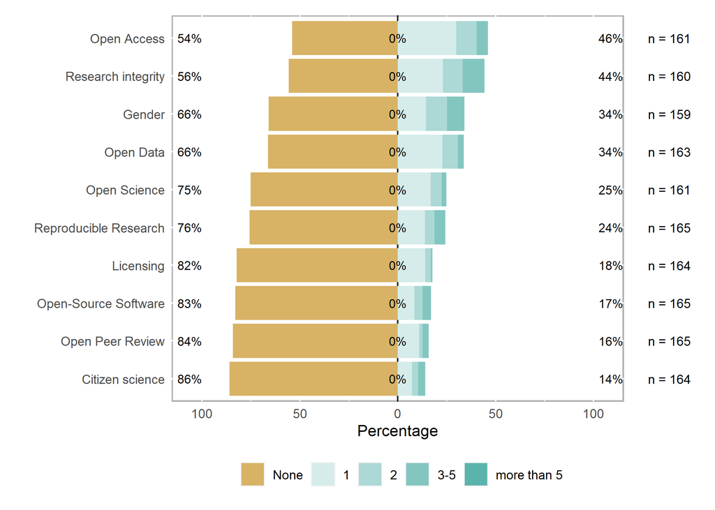

```r
answer_levels_b1 <- c("None", "1", "2", "3-5", "more than 5")


b1_df <- df %>%
  select(starts_with("B1["))

b1_df_rec <- b1_df %>%
  mutate(across(.fns = factor, levels = answer_levels_b1))


b1_df_rec %>%
  plot_likert(center_for_likert = 1.5, legend_rows = 1)
```

# B3 Attended Different Types of Training Sessions

How often did you attend the following types of training sessions?

| Variable | Never | Once | More than once |
| --- | --- | --- | --- |
| Blended learning course | 145 (86.8%) | 11 (6.6%) | 11 (6.6%) |
| Full day workshop | 101 (60.5%) | 23 (13.8%) | 43 (25.7%) |
| Half day workshop | 85 (50.9%) | 23 (13.8%) | 59 (35.3%) |
| MOOC (Massive Open Online Course) | 131 (78.4%) | 19 (11.4%) | 17 (10.2%) |
| Online course | 100 (59.9%) | 27 (16.2%) | 40 (24.0%) |
| Seminar | 80 (47.9%) | 27 (16.2%) | 60 (35.9%) |
| Several days workshop | 127 (76.0%) | 12 (7.2%) | 28 (16.8%) |
| Summer/ Winter School | 142 (85.0%) | 8 (4.8%) | 17 (10.2%) |
| Webinar | 73 (43.7%) | 22 (13.2%) | 72 (43.1%) |

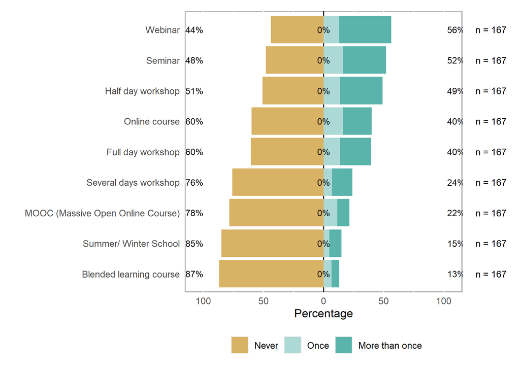

```r
answer_levels_b3 <- c("Never", "Once", "More than once")


b3_df <- df %>%
  select(starts_with("B3["))

b3_df_rec <- b3_df %>%
  mutate(across(.fns = factor, levels = answer_levels_b3))

b3_df_rec %>%
  plot_likert(center_for_likert = 1.5, legend_rows = 1)
```

# B5 Hours of training

How many hours of training in total did you get?

```r
# answer_levels_b5 <- c("None", "1", "2", "3-5", "More than 5", "Other")
# # remove "none" category, since these people did not receive training at all
answer_levels_b5 <- c("1", "2", "3-5", "More than 5")

b5_df <- df %>%
  select("B5")

b5_df_rec <- b5_df %>%
  mutate(across(.fns = factor, levels = answer_levels_b5))

recode_successful(b5_df, b5_df_rec)
```

[1] “Component "B5": Mean absolute difference: 50”

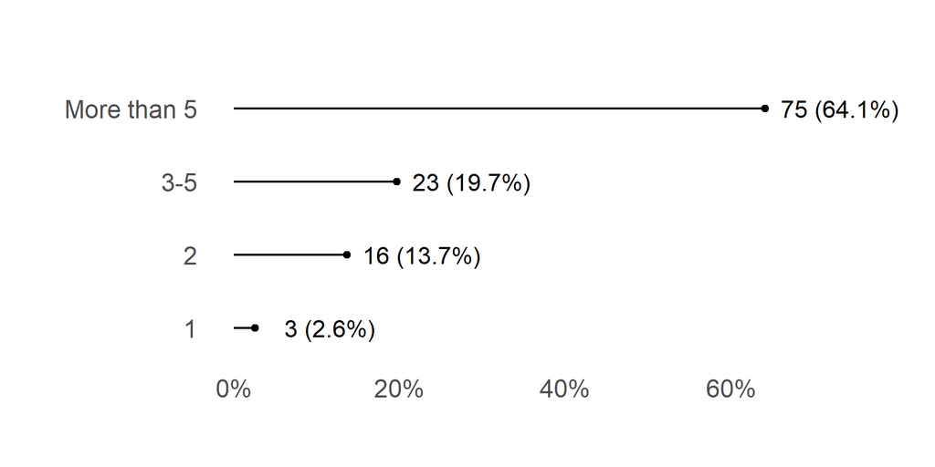

```r
b5_df_rec %>%
  plot_bar(B5, title = "Hours of training", reorder = FALSE, nudge_y = .09)
```